# GPA Prediction

-By Manish Shukla (mas180001@utdallas.edu)

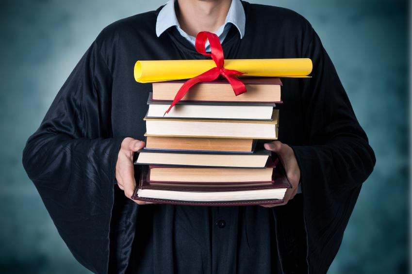

# Contents :

## 1. Data Import

## 2. Data Preprocessing

## 3. Exploratory Data Analysis

## 4. Data Modeling and Evaluation

## 5. Random Forest Regressor

## 6. Predicting the GPA's

- Importing all the required libraries for analysis

```python
#Importing Libraries for Analysis
import numpy as np
import pandas as pd
import matplotlib.pyplot as plt
from pandas.plotting import scatter_matrix
import scipy as sp
from scipy import stats
import seaborn as sns
from scipy.stats import norm
from sklearn.preprocessing import MinMaxScaler, StandardScaler
from sklearn.metrics import mean_squared_error
from sklearn.model_selection import train_test_split
from sklearn.linear_model import LinearRegression
from sklearn.model_selection import GridSearchCV

import warnings
warnings.filterwarnings('ignore')
```

# Step 1: Data Import

Data_train holds Train_GPA which will be used for traing and testing of the model, approx 8000 records  
Data_test holds Test_GPS which will be used for prediction after finding best model, exactly 200 records

```python
#Loading the data
data_train=pd.read_csv(r"C:\Users\manis\Desktop\Startup\Train_GPA.csv")
data_test=pd.read_csv(r"C:\Users\manis\Desktop\Startup\Test_GPA.csv")
```

- Checking the shape of both the datasets

```python
#Checking the Dimension
print(data_train.shape)
print(data_test.shape)
```

```
(7874, 12)
(200, 12)
```

- Checking the variables and initial records from datasets

```python
#Looking initials records of datasets
data_train.head()
```

|  | sat | tothrs | colgpa | athlete | verbmath | hsize | hsrank | hsperc | female | white | black | hsizesq |
| --- | --- | --- | --- | --- | --- | --- | --- | --- | --- | --- | --- | --- |
| 0 | 1130 | 42 | 2.02 | 0.0 | 0.85246 | 3.61 | 60 | 16.620500 | 1 | 1 | 0 | ? |
| 1 | 1120 | 58 | 3.13 | NaN | 0.96491 | 3.53 | 29 | 8.215298 | 1 | 1 | 0 | 12.4609 |
| 2 | 1180 | 17 | 2.76 | 0.0 | 0.76119 | 2.75 | 4 | 1.454545 | 0 | 1 | 0 | 7.5625 |
| 3 | 1020 | 78 | 2.87 | 0.0 | 1.21739 | 5.80 | 22 | 3.793103 | 1 | 1 | 0 | 33.64 |
| 4 | 810 | 16 | 2.43 | 0.0 | 0.92857 | 6.47 | 69 | 10.664610 | 1 | 1 | 0 | 41.8609 |

```python
#Looking initials records of datasets
data_test.head()
```

|  | sat | tothrs | colgpa | athlete | verbmath | hsize | hsrank | hsperc | female | white | black | hsizesq |
| --- | --- | --- | --- | --- | --- | --- | --- | --- | --- | --- | --- | --- |
| 0 | 920 | 43 | 2.04 | 1 | 0.48387 | 0.10 | 4 | 40.00000 | 1 | 0 | 0 | 0.0100 |
| 1 | 1170 | 18 | 4.00 | 0 | 0.82813 | 9.40 | 191 | 20.31915 | 0 | 1 | 0 | 88.3600 |
| 2 | 810 | 14 | 1.78 | 1 | 0.88372 | 1.19 | 42 | 35.29412 | 0 | 1 | 0 | 1.4161 |
| 3 | 940 | 40 | 2.42 | 0 | 0.80769 | 5.71 | 252 | 44.13310 | 0 | 1 | 0 | 32.6041 |
| 4 | 1180 | 18 | 2.61 | 0 | 0.73529 | 2.14 | 86 | 40.18692 | 0 | 1 | 0 | 4.5796 |

# Step 2: Data Preprocessing

Initially checking the null values in entire dataset, if any, dropping it

```python
#Checking null value in dataset
np.sum(data_train.isnull())
```

```
sat         0
tothrs      0
colgpa      0
athlete     2
verbmath    0
hsize       0
hsrank      0
hsperc      0
female      0
white       0
black       0
hsizesq     0
dtype: int64
```

```python
#Dropping the null values
data_train=data_train.dropna()
print(data_train.shape)
```

```
(7872, 12)
```

- Viewing the unique value in each column to find null value representation

```python
#Checking null values in each column
for col in data_train.columns:
    print('{} : {}'.format(col,data_train[col].unique()))
```

```
sat  : [1130 1180 1020  810  940  880  910 1490 1040 1220 1140 1170 1290 1340
 1110 1070 1200  950  970 1090  960  980 1010  890  780 1230 1160 1250
 1100 1050  990 1030  900 1060 1210  850  750 1280 1080 1000 1270  930
  540 1150  870  830  720 1330  920 1240  790  840  800  730 1360  700
 1120  860  820  760  680  740  670  690 1190 1350 1260 1310 1320 1380
 1430 1410  640  470 1440 1300  630 1370  770  500  710 1390  610 1450
  590 1460 1400  490 1420]
tothrs : [ 42  17  78  16  15  52 106  54  55  47  45 127  81  13  18  90  46  40
  83  35  41  14  73  97  84 129  38  32  80  57 117 108  50  29 125  76
  43 114 113  10  92  82  87  63  39  44 110 111  11  79  12 112  62  74
  95  88  49  98 121  72  58  64  96 102  89  71  53  51 126 120 131 123
 107 104  48  69  70  91  21  19 119 133 109  20 115  23  59 103  75  86
  99 118 134 100  36 116 105  66  85  68  94  67  77 122 124  65  61 101
  56  60  22  93 137  37   6 132  30 128  24  34  33 136  28 130   9]
colgpa : [2.02 2.76 2.87 2.43 3.06 2.75 2.46 4.   3.01 3.3  3.42 3.43 0.6  3.71
 3.38 2.62 3.49 2.53 3.77 2.65 2.67 2.35 2.05 2.31 2.92 2.94 3.28 2.72
 2.93 2.2  2.42 2.85 2.16 3.55 2.26 3.47 2.34 2.18 3.1  2.   3.03 3.32
 3.14 1.29 3.11 2.12 2.82 3.18 3.5  2.7  2.88 3.61 2.71 3.2  3.02 1.82
 1.41 3.76 1.93 2.69 1.5  3.16 3.29 3.31 3.46 2.27 3.62 1.91 2.9  3.13
 3.48 2.44 3.17 3.08 2.6  2.36 3.21 3.59 2.84 2.98 1.9  3.65 3.52 3.33
 3.   2.86 2.55 2.38 3.07 2.41 3.78 1.88 2.37 2.07 2.8  2.83 3.85 1.09
 2.3  2.33 3.41 1.06 1.8  2.97 2.51 0.55 2.06 2.22 3.27 2.56 2.64 1.56
 2.29 3.91 2.21 1.86 2.15 2.4  3.15 2.61 2.28 3.53 1.87 3.98 2.52 1.07
 2.04 2.5  3.12 2.11 2.23 3.64 3.09 1.83 1.37 2.78 2.25 3.34 3.86 1.92
 3.58 3.51 1.81 2.66 2.47 2.73 1.89 3.45 1.72 3.25 2.99 2.68 3.93 3.73
 2.39 0.25 3.95 2.1  2.96 1.98 3.22 2.13 2.58 3.24 1.14 1.63 1.64 1.69
 3.26 2.17 2.54 1.97 1.6  2.08 3.57 3.88 2.81 2.79 2.95 2.74 3.35 3.8
 3.44 2.59 3.66 1.77 3.87 2.57 1.36 3.4  2.48 3.37 1.76 3.82 2.45 2.89
 1.95 3.83 3.05 3.75 2.77 1.2  2.24 1.58 3.63 1.21 1.73 2.91 2.63 1.62
 3.23 3.39 3.04 3.97 3.94 1.94 1.79 3.68 1.84 2.09 3.67 1.68 3.6  3.92
 1.61 1.75 1.74 1.66 1.13 1.51 0.85 1.17 3.84 3.36 1.4  1.7  1.05 1.3
 1.26 1.   2.01 1.85 1.44 2.49 3.9  3.56 2.14 2.32 3.81 1.59 1.55 1.96
 1.31 2.03 1.57 1.71 1.99 0.75 0.8  1.43 3.72 3.54 2.19 1.23 1.38 1.53
 0.92 1.15 0.3  0.46 1.35 1.46 3.7  0.84 1.18 0.76 1.52 1.67 3.79 0.53
 1.28 0.64 1.45 0.86 0.87 3.19 0.28 1.25 0.72 3.74 1.33 1.54 0.41 0.91
 1.42 3.69 0.81 0.7  0.58 0.66 1.39 1.65 3.96 0.94 0.   0.93 1.27 0.68
 0.73 0.4  1.22 0.35 0.21]
athlete : [0. 1.]
verbmath : [0.85246 0.76119 1.21739 0.92857 0.84314 0.83333 0.89583 0.98667 0.76271
 0.74286 0.72727 0.8     0.82    0.79167 0.78667 0.65672 0.92593 0.67188
```

[output cut: 228 more lines]

```
 '0.2025' '0.9409' '0.09' '0.4356' '32.49' '11.0224' '4.7089' '2.2201'
 '0.0729' '0.0576' '0.0324' '4.0804' '1.3689' '1.7689' '10.1124' '10.8241'
 '1.1664' '1.21' '0.1225' '0.4761' '21.6225' '19.5364' '0.3481' '0.49'
 '0.7056' '7.3441' '29.0521' '5.9536' '0.3249' '7.3984' '0.0121' '0.0625'
 '8.3521' '6.9169' '3.1684' '0.3969' '0.0529' '28.5156' '16.7281' '1.1236'
 '13.5424' '3.9204' '0.1089' '27.6676' '28.9444' '0.1681' '0.2601'
 '0.0256' '0.3025' '0.0064' '47.1969' '51.1225' '33.4084' '0.4489'
 '11.6281' '8.5849' '1.3456' '1.0816' '0.3844' '0.0049' '2.3409' '0.4225'
 '0.1849' '0.2916' '48.7204' '8.2369' '17.2225' '26.8324' '34.1056'
 '22.7529' '30.3601' '51.9841' '34.5744' '36.6025' '64.6416' '47.61'
 '45.2929' '40.1956' '32.7184' '46.5124' '33.5241' '39.1876' '31.36'
 '14.2884' '55.0564' '28.3024' '55.6516' '29.7025' '44.3556' '65.61'
 '65.9344' '56.1001' '77.7924' '24.01' '9.3636' '49.1401' '85.7476'
 '60.2176' '51.5524' '34.6921' '20.4304' '25.7049' '21.3444' '31.1364'
 '23.7169' '33.8724' '31.0249' '29.3764' '30.5809' '16.4836' '40.8321']
```

- No Values are represented by '?', dropping it

```python
#Dropping the missing values
for col in data_train.columns:
    data_train=data_train[data_train[col]!='?']

print(data_train.shape)
```

```
(7870, 12)
```

- Displaying stats of the each variable in dataset to check mean
- Since mean of any varaible is not zero, not dropping any varaible
- Variable with 0 mean add no significance in analysis

```python
data_train.describe()
```

|  | sat | tothrs | colgpa | athlete | verbmath | hsize | hsrank | hsperc | female | white | black |
| --- | --- | --- | --- | --- | --- | --- | --- | --- | --- | --- | --- |
| count | 7870.000000 | 7870.000000 | 7870.000000 | 7870.000000 | 7870.000000 | 7870.000000 | 7870.000000 | 7870.000000 | 7870.000000 | 7870.000000 | 7870.000000 |
| mean | 1030.144854 | 53.047014 | 2.652229 | 0.040152 | 0.880400 | 2.798872 | 51.892249 | 18.838805 | 0.451080 | 0.925540 | 0.056925 |
| std | 138.860363 | 35.400604 | 0.658406 | 0.196329 | 0.148305 | 1.732140 | 63.832846 | 16.344302 | 0.497633 | 0.262535 | 0.231714 |
| min | 470.000000 | 6.000000 | 0.000000 | 0.000000 | 0.259740 | 0.040000 | 1.000000 | 0.166667 | 0.000000 | 0.000000 | 0.000000 |
| 25% | 940.000000 | 17.000000 | 2.210000 | 0.000000 | 0.775860 | 1.650000 | 10.000000 | 6.281573 | 0.000000 | 1.000000 | 0.000000 |
| 50% | 1020.000000 | 47.000000 | 2.660000 | 0.000000 | 0.866670 | 2.510000 | 30.000000 | 14.285710 | 0.000000 | 1.000000 | 0.000000 |
| 75% | 1120.000000 | 81.000000 | 3.120000 | 0.000000 | 0.964910 | 3.650000 | 69.000000 | 26.994605 | 1.000000 | 1.000000 | 0.000000 |
| max | 1490.000000 | 137.000000 | 4.000000 | 1.000000 | 1.666670 | 9.260000 | 634.000000 | 92.000000 | 1.000000 | 1.000000 | 1.000000 |

```python
data_train.info()
```

```
<class 'pandas.core.frame.DataFrame'>
Int64Index: 7870 entries, 2 to 7873
Data columns (total 12 columns):
sat         7870 non-null int64
tothrs      7870 non-null int64
colgpa      7870 non-null float64
athlete     7870 non-null float64
verbmath    7870 non-null float64
hsize       7870 non-null float64
hsrank      7870 non-null int64
hsperc      7870 non-null float64
female      7870 non-null int64
white       7870 non-null int64
black       7870 non-null int64
hsizesq     7870 non-null object
dtypes: float64(5), int64(6), object(1)
memory usage: 799.3+ KB
```

# Step 3: Exploratory Data Analysis

Visualizing the data relation and distribution between each columns

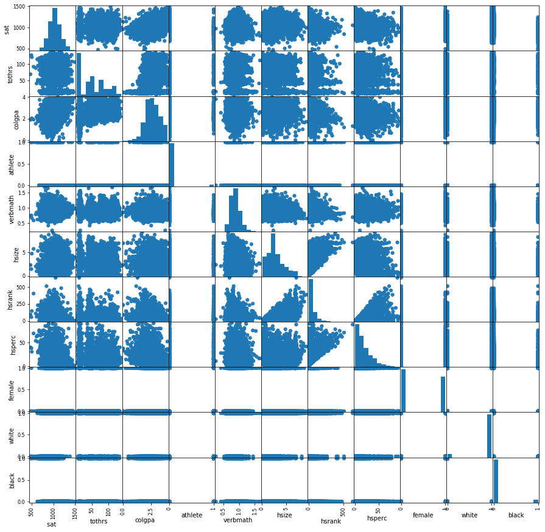

```python
scatter_matrix(data_train, figsize = (15,15),alpha = 0.8, marker = 'O')
plt.show()
```

- Generating the Heatmap to see the relation between varaibles
- Found that varaible white and black are negatively correlated, so dropping column 'Black'

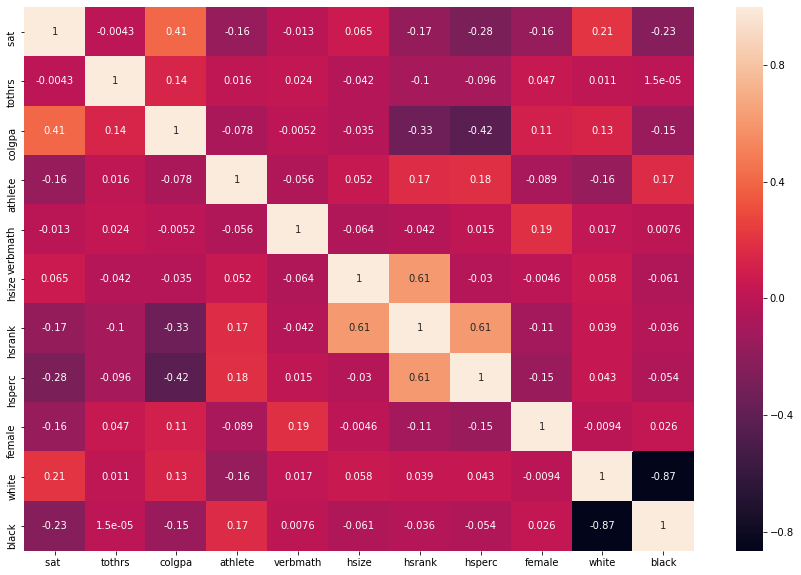

```python
plt.figure(figsize=(15,10))
sns.heatmap(data_train.corr(), annot=True)
```

```python
data_train=data_train.drop(columns='black', axis=1)
print(data_train.shape)
```

```
(7870, 11)
```

- Plotting the box-plot for variables to view the outliers

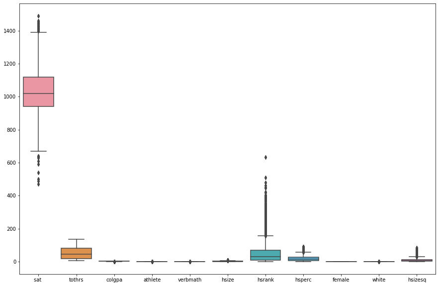

```python
plt.figure(figsize=(15,10))
sns.boxplot(data=data_train)
```

- Plotting histogram to see the shape of distribution for varaibles

```
array([[<matplotlib.axes._subplots.AxesSubplot object at 0x000002297950AE48>,
      dtype=object)
```

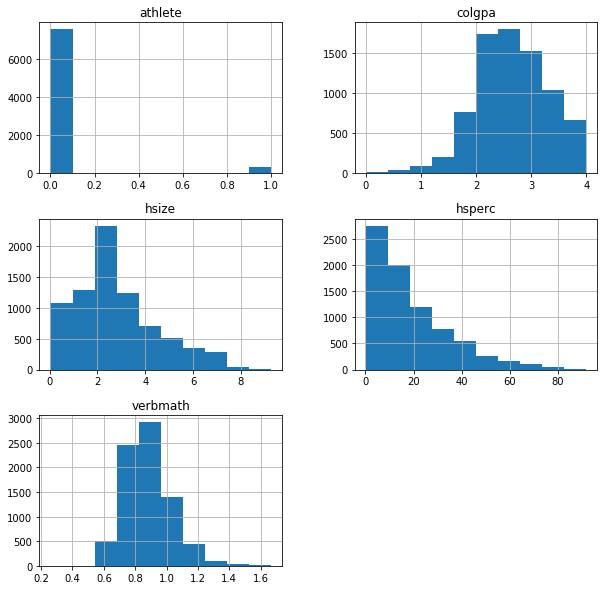

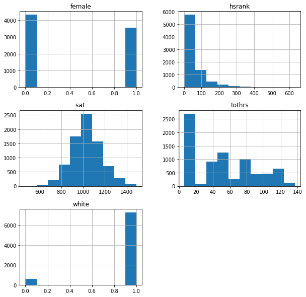

```python
data_train[data_train.dtypes[(data_train.dtypes=="float")].index.values].hist(figsize=[10,10])
data_train[data_train.dtypes[(data_train.dtypes=="int64")].index.values].hist(figsize=[10,10])
```

# Step 4: Data Modeling and Evaluation

Separating the target and independent variables

```python
train_ind=data_train.drop(columns=['colgpa'], axis=1)
train_dep=data_train['colgpa']
print(train_ind.shape)
print(train_dep.shape)
```

```
(7870, 10)
(7870,)
```

- Displaying the data view for Train Independent and Train Dependent set

```python
train_ind.head(5)
```

|  | sat | tothrs | athlete | verbmath | hsize | hsrank | hsperc | female | white | hsizesq |
| --- | --- | --- | --- | --- | --- | --- | --- | --- | --- | --- |
| 2 | 1180 | 17 | 0.0 | 0.76119 | 2.75 | 4 | 1.454545 | 0 | 1 | 7.5625 |
| 3 | 1020 | 78 | 0.0 | 1.21739 | 5.80 | 22 | 3.793103 | 1 | 1 | 33.64 |
| 4 | 810 | 16 | 0.0 | 0.92857 | 6.47 | 69 | 10.664610 | 1 | 1 | 41.8609 |
| 5 | 940 | 15 | 0.0 | 0.84314 | 2.34 | 14 | 5.982906 | 1 | 1 | 5.4756 |
| 6 | 880 | 16 | 0.0 | 0.83333 | 3.21 | 51 | 15.887850 | 1 | 1 | 10.3041 |

```python
train_dep.head(5)
```

```
2    2.76
3    2.87
4    2.43
5    3.06
6    2.75
Name: colgpa, dtype: float64
```

```python
# Splitting the data into train and test
X_train_unscaled, X_test_unscaled, y_train, y_test = train_test_split(train_ind,train_dep,test_size=0.25,random_state=2)

# Scaling the data
scaler=MinMaxScaler()
X_train=scaler.fit_transform(X_train_unscaled)
X_test=scaler.transform(X_test_unscaled)

print(X_train.shape)
print(y_train.shape)
print(X_test.shape)
print(y_test.shape)
```

```
(5902, 10)
(5902,)
(1968, 10)
(1968,)
```

- Training the model for Linear Regression

```python
# Fitting the data using Linear Regression
regressor = LinearRegression()
regressor.fit(X_train,y_train)
```

```
LinearRegression(copy_X=True, fit_intercept=True, n_jobs=None, normalize=False)
```

- Generating the Model Evaluation Parameter for Linear Regression
- We see that, evaluation parameters do not show much significance for Linear Regression

```python
print('Train Score {}'.format(regressor.score(X_train, y_train)))
print('Test Score {}\n'.format(regressor.score(X_test, y_test)))
print('linear model coeff (w): {}\n'.format(regressor.coef_))
print('linear model intercept (b): {:.3f}\n'.format(regressor.intercept_))
print('R-squared score (training): {:.3f}\n'.format(regressor.score(X_train, y_train)))
print('R-squared score (test): {:.3f}'.format(regressor.score(X_test, y_test)))
print('Mean Squared Error : {}'.format(mean_squared_error(y_test,regressor.predict(X_test))))
```

```
Train Score 0.31581759792736375
Test Score 0.3005513135217669

linear model coeff (w): [ 1.58869036  0.23187101  0.2149201  -0.12821275 -0.24224778 -0.91340784
 -0.91481798  0.15323938  0.20805632  0.40224079]

linear model intercept (b): 1.766

R-squared score (training): 0.316

R-squared score (test): 0.301
Mean Squared Error : 0.3082026096939786
```

- Plotting the visuals for Linear Regression

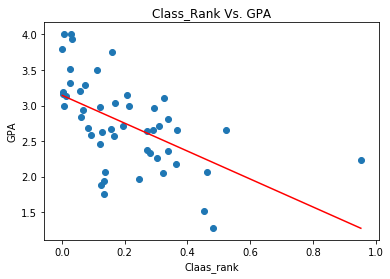

```python
X_b = X_train[:50,6].reshape(-1,1)
y_b = y_train[:50]

regressor = LinearRegression()

regressor.fit(X_b, y_b)
X_new=np.linspace(X_b.min(), X_b.max(), 50).reshape(50, 1)
y_predict = regressor.predict(X_new)

plt.plot(X_new, y_predict, c = 'r',label='Prediction')
plt.scatter(X_b, y_b,label='Actual Data Points')
plt.xlabel('Claas_rank')
plt.ylabel('GPA')
plt.title('Class_Rank Vs. GPA')
```

- Using Grid Search, for making the model better
- Still no much improvement

```python
param_grid = {'fit_intercept':[True,False], 'normalize':[True,False], 'copy_X':[True, False]}
grid_search = GridSearchCV(regressor , param_grid, cv = 5 , return_train_score=True)
grid_search.fit(X_train, y_train)
grid_search.best_params_
print('Train Score {}'.format(grid_search.score(X_train,y_train)))
print('Test Score {}'.format(grid_search.score(X_test,y_test)))
```

```
Train Score 0.31581759792736375
Test Score 0.3005513135217668
```

# Step 5: Random Forest Regressor

- Using random forest ensemble method to make model better, by using cross validation in it
- Visualizing target variable distribution, looks normally distributed

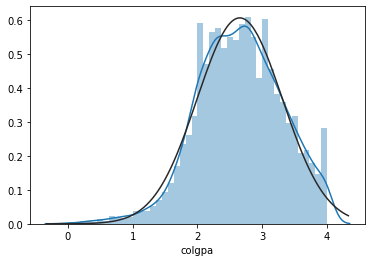

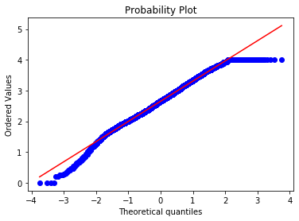

```python
sns.distplot(data_train['colgpa'],fit=norm);
fig = plt.figure()
res = stats.probplot(data_train['colgpa'], plot=plt)
```

- Building Random Forest with different estimators and trying to get best

```python
from sklearn.ensemble import RandomForestRegressor as rfr
from sklearn.model_selection import cross_val_score
estimators = [10, 30, 50, 70, 100]
mean_rfrs = []
std_rfrs_upper = []
std_rfrs_lower = []
yt = [i for i in y_train]
np.random.seed(11111)
for i in estimators:
    model = rfr(n_estimators=i,max_depth=None)
    scores_rfr = cross_val_score(model,X_train,yt,cv=100,scoring='explained_variance')
    print('estimators:',i)
    print("Est. explained variance: %0.2f (+/- %0.2f)" % (scores_rfr.mean(), scores_rfr.std() * 2))
    print('')
    mean_rfrs.append(scores_rfr.mean())
    std_rfrs_upper.append(scores_rfr.mean()+scores_rfr.std()*2)
    std_rfrs_lower.append(scores_rfr.mean()-scores_rfr.std()*2)
```

```
estimators: 10
Est. explained variance: 0.70 (+/- 0.17)

estimators: 30
Est. explained variance: 0.73 (+/- 0.15)

estimators: 50
Est. explained variance: 0.73 (+/- 0.17)

estimators: 70
Est. explained variance: 0.74 (+/- 0.16)

estimators: 100
Est. explained variance: 0.74 (+/- 0.16)
```

- Visualizing the different estimators and plotting the variablity explained

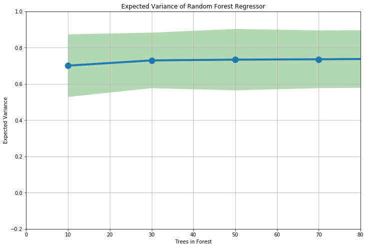

```python
fig = plt.figure(figsize=(12,8))
ax = fig.add_subplot(111)
ax.plot(estimators,mean_rfrs,marker='o',
       linewidth=4,markersize=12)
ax.fill_between(estimators,std_rfrs_lower,std_rfrs_upper,
                facecolor='green',alpha=0.3,interpolate=True)
ax.set_ylim([-.2,1])
ax.set_xlim([0,80])
plt.title('Expected Variance of Random Forest Regressor')
plt.ylabel('Expected Variance')
plt.xlabel('Trees in Forest')
plt.grid()
plt.show()
```

- Building the model on the best parameters and training the model

```python
from sklearn.ensemble import RandomForestRegressor

rfr = RandomForestRegressor(n_estimators = 100, random_state = 100)
rfr.fit(X_train, y_train);
```

- Testing the test data on fitted model and getting model evaluation parameters
- Calculated Mean Absolute Error and Mean Squared Error, to get efficiency of the model

```python
predictions = rfr.predict(X_test)

errors = abs(predictions - y_test)
print('Mean Absolute Error:', round(np.mean(errors), 2))
print('Mean Squared Error : {}'.format(mean_squared_error(y_test,predictions)))
print('score (training): {:.3f}\n'.format(rfr.score(X_train, y_train)))
print('score (test): {:.3f}'.format(rfr.score(X_test, y_test)))
```

```
Mean Absolute Error: 0.23
Mean Squared Error : 0.10498535670223573
score (training): 0.963

score (test): 0.762
```

# Step 6: Predicting the GPA's

pre-processing 200 records(Test data) to predict the GPA for them

```python
data_test.shape
```

```
(200, 12)
```

```python
data_test.head()
```

|  | sat | tothrs | colgpa | athlete | verbmath | hsize | hsrank | hsperc | female | white | black | hsizesq |
| --- | --- | --- | --- | --- | --- | --- | --- | --- | --- | --- | --- | --- |
| 0 | 920 | 43 | 2.04 | 1 | 0.48387 | 0.10 | 4 | 40.00000 | 1 | 0 | 0 | 0.0100 |
| 1 | 1170 | 18 | 4.00 | 0 | 0.82813 | 9.40 | 191 | 20.31915 | 0 | 1 | 0 | 88.3600 |
| 2 | 810 | 14 | 1.78 | 1 | 0.88372 | 1.19 | 42 | 35.29412 | 0 | 1 | 0 | 1.4161 |
| 3 | 940 | 40 | 2.42 | 0 | 0.80769 | 5.71 | 252 | 44.13310 | 0 | 1 | 0 | 32.6041 |
| 4 | 1180 | 18 | 2.61 | 0 | 0.73529 | 2.14 | 86 | 40.18692 | 0 | 1 | 0 | 4.5796 |

```python
np.sum(data_test.isnull())
data_test=data_test.dropna()
```

```python
for col in data_test.columns:
    print('{} : {}'.format(col,data_test[col].unique()))
```

```
sat  : [ 920 1170  810  940 1180  980  880 1240 1230 1140 1150 1080  990 1000
 1050 1160 1190 1030  960  840 1040  970 1200 1090 1340  740  820 1060
  730  780  870 1020 1100  910 1010  700  930  900 1120  890  790  850
 1540 1280 1260  830  500  570 1310  770 1130 1110 1210  650  720 1070
  950 1270 1220 1300  860 1290 1320 1410]
tothrs : [ 43  18  14  40 114  78  55  17  64  45  41  13 110 106 104 115  96  50
 100 112  39 118  46  12  85  42  16  71  19  47 103 105  72  15  38  29
  79  37 113  48  95  86  83  53  63 122  20  54  81  76  52  77  87  49
  36  74  80  73 108  35 107 102  44  92  94 117  69  93  75  32  11 116
 126  70]
colgpa : [2.04 4.   1.78 2.42 2.61 3.03 1.84 3.05 3.   2.   2.98 2.93 2.21 3.33
 1.07 2.29 3.15 2.65 2.41 2.39 2.64 2.18 2.84 2.38 3.92 2.23 1.33 2.81
 2.09 2.25 1.9  2.4  2.16 2.07 2.91 2.72 3.55 3.25 2.86 1.92 3.58 3.46
 3.16 1.03 2.33 2.45 3.65 3.61 3.81 2.82 2.3  3.27 2.66 2.26 2.37 3.87
 1.95 2.43 1.21 1.75 1.73 2.13 3.77 3.22 2.17 2.77 3.36 3.62 3.7  3.69
 2.19 3.4  1.43 2.78 3.09 2.83 1.93 2.88 3.31 2.92 3.52 2.28 3.02 3.32
 2.03 2.34 3.41 2.56 2.6  2.63 2.58 3.04 2.76 2.73 2.54 3.06 3.23 2.22
 1.99 3.14 3.24 2.5  1.6  2.69 2.94 3.44 3.12 3.64 2.57 3.43 2.24 3.29
 2.31 1.88 2.47 1.   2.02 3.68 1.97 2.12 3.66 1.8  2.48 2.97 1.7  1.98
 3.37 2.15 1.81 3.56 3.11 2.11 2.75 3.72]
athlete : [1 0]
verbmath : [0.48387 0.82813 0.88372 0.80769 0.73529 0.81481 0.76    0.88462 0.69863
 0.86364 0.9322  0.85484 0.8     0.67797 0.78571 0.77966 0.87097 1.125
 1.10204 1.      0.64706 0.86667 0.79688 0.96226 0.7963  0.90476 0.75806
 0.83562 1.3125  0.90698 0.85965 0.78049 0.69565 1.03922 1.175   1.29268
 0.92157 0.96154 0.87302 1.11538 1.04255 1.45946 0.96296 1.37838 0.94231
 0.86    0.91489 0.91228 1.24    0.77778 0.78    0.7971  0.84746 1.10256
 0.77358 0.67241 1.07895 1.11765 0.80851 0.70833 0.67164 1.09524 0.97436
 1.03175 0.75    0.84444 0.68966 1.27273 0.82353 0.96552 0.82222 0.95522
 0.7907  0.92647 1.12963 0.91525 1.09434 1.01667 1.01852 0.82456 1.0303
 0.80556 0.67606 0.73684 0.73134 0.58333 1.18519 0.83607 0.77193 0.9661
 1.10526 0.94595 0.91935 0.76364 0.95161 0.72222 0.85185 0.88235 1.27907
 0.92    0.73214 0.93333 0.6875  0.79365 0.89286 0.63492 0.78333 0.75439
 0.55072 0.66667 0.86885 0.70909 0.71429 0.93478 0.89831 0.8254  0.78873
 0.83333 0.94915 0.84848 0.7541  1.01961 0.63333 0.98077 0.80328 0.92982
 0.91071 1.12766 1.01695 0.65625 0.85075 0.86275 0.45763 0.74138 0.76119
 0.74576 0.77143 0.91379 0.87719 0.89091 1.08065 0.83636 0.74194 0.62319
 0.75362 0.98    0.73846 0.78723 0.875   0.88679 1.37209 0.68421 1.225
 0.72414 0.76271 1.02381 0.84211 0.96491 0.92727 1.25    0.94545 1.05455
 0.90541 1.01786]
```

[output cut: 63 more lines]

```
 5.32900e-01 1.71610e+00 2.38144e+01 1.65649e+01 5.29000e+00 1.20409e+01
 4.12090e+00 4.00000e+00 8.46400e-01 2.08849e+01 1.30321e+01 1.05625e+01
 1.04976e+01 9.18090e+00 2.18089e+01 1.00000e+00 2.30400e+01 1.02400e+01
 9.12040e+00 2.75560e+00 4.16160e+00 8.58490e+00 3.49690e+00 1.26025e+01
 1.23210e+00 7.39600e-01 4.24360e+00 1.79776e+01 6.30010e+00 5.80810e+00
 2.19961e+01 1.01761e+01 1.61604e+01 1.86624e+01 1.84900e+01 6.81210e+00
 1.16281e+01 2.61121e+01 5.56960e+00 1.87489e+01 5.10760e+00 5.47600e-01
 4.49440e+00 9.30250e+00 5.52250e+00 8.70250e+00 7.72840e+00 9.92250e+00
 1.39129e+01 1.37641e+01 1.68100e+01 3.60000e+01 8.12250e+00 2.43360e+00
 4.41000e+00 1.07584e+01 2.25000e+00 1.84960e+00 7.34410e+00 9.48640e+00
 9.36360e+00 3.16840e+00 5.15290e+00 8.64360e+00 7.50760e+00 6.55360e+00
 3.80250e+00 3.84160e+00 3.36400e-01 2.30400e-01 5.33610e+00 2.60100e-01
 1.18336e+01 1.60801e+01 1.21000e+00 3.02500e+01 3.84400e+01 5.89824e+01
 7.29316e+01 2.59210e+00 3.20410e+00 7.29000e+00 4.36921e+01 1.60000e-01
 2.62144e+01 3.41056e+01 1.54449e+01]
```

```python
for col in data_test.columns:
    data_test=data_test[data_test[col]!='?']
```

- Splitting the data to get prediction

```python
data_test=data_test.drop(columns='black', axis=1)
test_ind=data_test.drop(columns=['colgpa'], axis=1)
test_dep=data_test['colgpa']
```

- Predicting the GPA's on trained model and best parameters

```python
predictions=rfr.predict(test_ind)
df=pd.DataFrame(predictions)
predictions.shape
```

```
(200,)
```

- Displaying the predicted GPA

```python
df
```

|  | 0 |
| --- | --- |
| 0 | 2.8004 |
| 1 | 2.4779 |
| 2 | 2.4779 |
| 3 | 2.4779 |
| 4 | 2.4779 |
| 5 | 2.5132 |
| 6 | 2.4493 |
| 7 | 2.4779 |
| 8 | 2.4779 |
| 9 | 2.7235 |
| 10 | 2.5132 |
| 11 | 2.5132 |
| 12 | 2.4779 |
| 13 | 2.5132 |
| 14 | 2.5132 |
| 15 | 2.5132 |
| 16 | 2.5132 |
| 17 | 2.4779 |
| 18 | 2.5132 |
| 19 | 2.4779 |
| 20 | 2.4779 |
| 21 | 2.5132 |
| 22 | 2.5132 |
| 23 | 2.4779 |
| 24 | 2.5132 |
| 25 | 2.4779 |
| 26 | 2.5132 |
| 27 | 2.5132 |
| 28 | 2.5943 |
| 29 | 2.4779 |
| ... | ... |
| 170 | 2.4140 |
| 171 | 2.4779 |
| 172 | 2.6606 |
| 173 | 2.5120 |
| 174 | 2.4779 |
| 175 | 2.5132 |
| 176 | 2.4779 |
| 177 | 2.6655 |
| 178 | 2.5132 |
| 179 | 2.4779 |
| 180 | 2.5132 |
| 181 | 2.5132 |
| 182 | 2.4806 |
| 183 | 2.5132 |
| 184 | 2.7687 |
| 185 | 2.5132 |
| 186 | 2.4779 |
| 187 | 2.4779 |
| 188 | 2.4779 |
| 189 | 2.5132 |
| 190 | 2.4779 |
| 191 | 2.5132 |
| 192 | 2.5132 |
| 193 | 2.4779 |
| 194 | 2.6534 |
| 195 | 2.5132 |
| 196 | 2.4779 |
| 197 | 2.4779 |
| 198 | 2.4779 |
| 199 | 2.4779 |

200 rows × 1 columns

---------------********---------------